# Research Design

## Experimental research design

#### Quantitative designs

- Tests causal effects using random assignment.
- Video example: fertilizer type and plant growth.
- Research question: Which fertilizer causes the largest growth gain?
- Research proposal: Randomly assign 120 plants to 4 conditions.
- Perspective: strongest internal-validity design for causality.

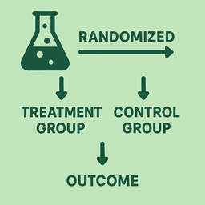

## Experimental research design

#### Quantitative designs

- Define treatments, controls, and outcome measures.
- Standardize procedures across all conditions.
- Collect pre/post data and monitor protocol fidelity.
- Analyze with mean tests and effect sizes.
- Output: causal estimate plus uncertainty bounds.

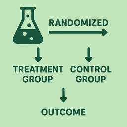

## Quantitative content analysis

#### Quantitative designs

- Quantifies document content with predefined categories.
- Example: count themes in media stories about immigration.
- Research question: Which themes dominate media coverage over time?
- Research proposal: Code 500 articles from 5 outlets.
- Perspective: systematic, replicable, category-based measurement.

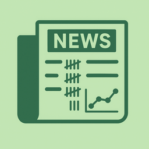

## Quantitative content analysis

#### Quantitative designs

- Build codebook and clear coding rules first.
- Sample documents by source and date windows.
- Code actors, words, themes, and stance categories.
- Aggregate counts into tables and trend graphs.
- Output: comparable indicators across outlets and periods.

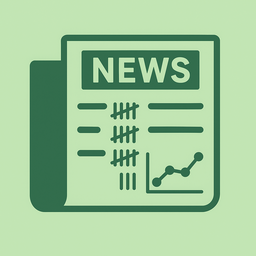

Mixed Methods Research Designs

## Convergent parallel design

#### Mixed designs

- Convergent parallel design collects qual and quant data in one phase.
- Example: satisfaction survey plus short interviews with participants.
- Research question: What is satisfaction level, and why do frustrations persist?
- Perspective: pragmatic integration of breadth (numbers) and depth (narratives).
- Goal: triangulate findings and build a fuller account.

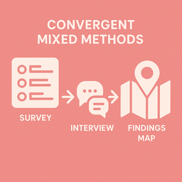

## Convergent parallel design

#### Mixed designs

- Collection is concurrent: surveys and interviews in the same timeframe.
- Analysis is separate first, then integrated across datasets.
- Example: 1-10 satisfaction scores linked to interview explanations.
- Compare agreement, contradiction, and added context.
- Output: one interpretation that combines both evidence streams.

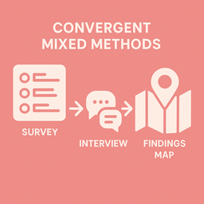

## Explanatory sequential design

#### Mixed designs

- Explanatory sequential design runs quant first, then qual follow-up.
- Example: survey online-learning challenges, then interview key groups.
- Research question: Which issues are most common, and why do they occur?
- Perspective: pragmatic and explanation-focused.
- Sequence: QUAN -> qual for elaboration of patterns.

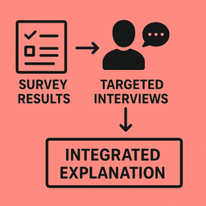

## Explanatory sequential design

#### Mixed designs

- Phase 1: survey key variables (challenges, ratings, usage).
- Analyze Phase 1 to find trends and outliers.
- Phase 2: interview selected participants for explanation.
- Analyze narratives to explain quant patterns and mechanisms.
- Integration: numbers show what; interviews explain why.

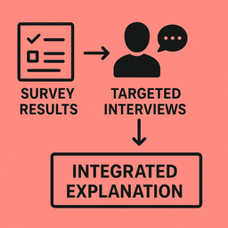

## Exploratory sequential design

#### Mixed designs

- Exploratory sequential design starts qual, then tests with quant.
- Example: interviews suggest a loyalty idea, then survey its impact.
- Research question: Which themes emerge, and how common are they at scale?
- Perspective: inductive discovery followed by confirmatory testing.
- Sequence: QUAL -> quan with instrument development.

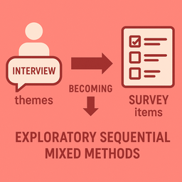

## Exploratory sequential design

#### Mixed designs

- Phase 1: interviews/focus groups generate candidate themes.
- Code Phase 1 data into constructs for survey items.
- Phase 2: test prevalence, relationships, or impact in larger samples.
- Example: convert loyalty-theme insights into measurable variables.
- Integration: qual defines measures; quant tests generalizability.

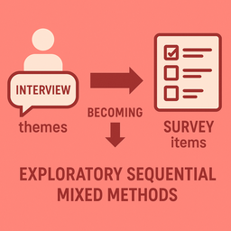

## AI use in academic work

- OK: brainstorm ideas, do research
- OK: generate project materials
- OK: data analysis, statistics tools
- Not OK: copy-paste text to your exam
- Not OK: generate fake empirical data
- Not OK: upload content you dont own
- Not OK: upload data with personal info
- https://gemini.google.com/

## Open science methods

- **Replicability**: Python enables reproducible research with shareable scripts.
- **Transparency**: Open-source code makes analyses fully visible.
- **Collaboration**: Supports teamwork via GitHub and Jupyter Notebooks.
- **Open Source**: Free and community-driven for open science. 🚀

## Next steps

**Workshop 1, feb 20**

- Lecture notes: https://cca-cce.github.io/osm-comm/web/edu/skoc62-lecture1.html
- Workshop: [canvas page](https://canvas.education.lu.se/courses/37916/pages/workshop-om-forskningsdesign?module_item_id=1701649) (moved to next workshop feb 24)

**References**

6, P., and C. Bellamy. 2011. *Principles of Methodology: Research Design in Social Science*. Principles of Methodology: Research Design in Social Science. SAGE Publications. https://books.google.se/books?id=IWQ0wwEACAAJ.

Djurfeldt, Göran, Rolf Larsson, and Ola Stjärnhagen. 2003. “Statistisk Verktygslåda-Samhällsvetenskaplig Orsaksanalys Med Kvantitativa Metoder.”

Trost, Jan, and Oscar Hultåker. 2016. *Enkätboken*. Femte upplagan. Lund: Studentlitteratur.